# Coursework Report

*N* removed NAs: 2

*N* removed typo: 1

*N* removed <18: 28

*N* total clean: 120

| Group | *N* | *M*<sub>age</sub> | *M*<sub>rating</sub> |
| --- | --- | --- | --- |
| Control | 58 | 21.12 | 5.53 |
| Experim | 62 | 21.53 | 6.40 |

**Main analysis results**

*t*(118) = -6.97, *p* < .001

[interactive chart not shown]

[figure not shown]

[interactive chart not shown]

# Coursework Report

Analysing Data, Spring 2020

# Methods

## Participants

| Group Conditions | *N* | % | *M*<sub>AGE</sub> | *SD*<sub>Age</sub> | *MIN*<sub>Age</sub> | *MAX*<sub>Age</sub> |
| --- | --- | --- | --- | --- | --- | --- |
| White | 58 | 48.33 | 21.12 | 2.54 | 18 | 30 |
| Red | 62 | 51.67 | 21.53 | 2.29 | 18 | 28 |

Figure 1. Table showing participant data, including the number of participants as well as their average age relative to their experimental condition.

## Design

The aim of this study was to find whether women find men more attractive when in conjuncture with the colour red relative to achromatic colours. Thus, to measure this, a scale of 1-9 was been used (1= not at all attractive, 9= very attractive) to interpret how attractive the participants found men. Participants, between-groups, viewed 3 images of men with either red (N=62) or white (N=58) borders. And so, the hypothesis becomes “there will be a difference between the mean ratings of attractiveness between photos with a red border compared to a white border” this will be tested by performing a statistical analysis using a t-test to find if there is a significant difference between the ratings of attractiveness.

# Results

| Group Condition | Overall *M*<sub>Rating</sub> | Overall *SD*<sub>Rating</sub> |
| --- | --- | --- |
| White | 5.53 | 0.66 |
| Red | 6.40 | 0.71 |

Figure 2. Shows the composite score calculated from the of mean and standard deviation from all models by each group condition.

After the participants gave their ratings on the attractiveness of the 3 models with either a red or white border, we have concluded the analysis of the results using an independent-measures t-test. The findings of the study show a significant difference between the rating (*M*<sub>diff</sub> = 0.87, 95% CI [-1.12, -0.63], *t* (118) = -6.97, *p* = 0). The meaning of this is that the rating of men in the red condition (*M* = 6.4) was significantly greater than that in the white condition (*M* = 5.53), implying that when a man is seen in conjuncture with the colour red they are more likely to be seen as more attractive than if seen with an achromatic colour instead, supporting the hypothesis.

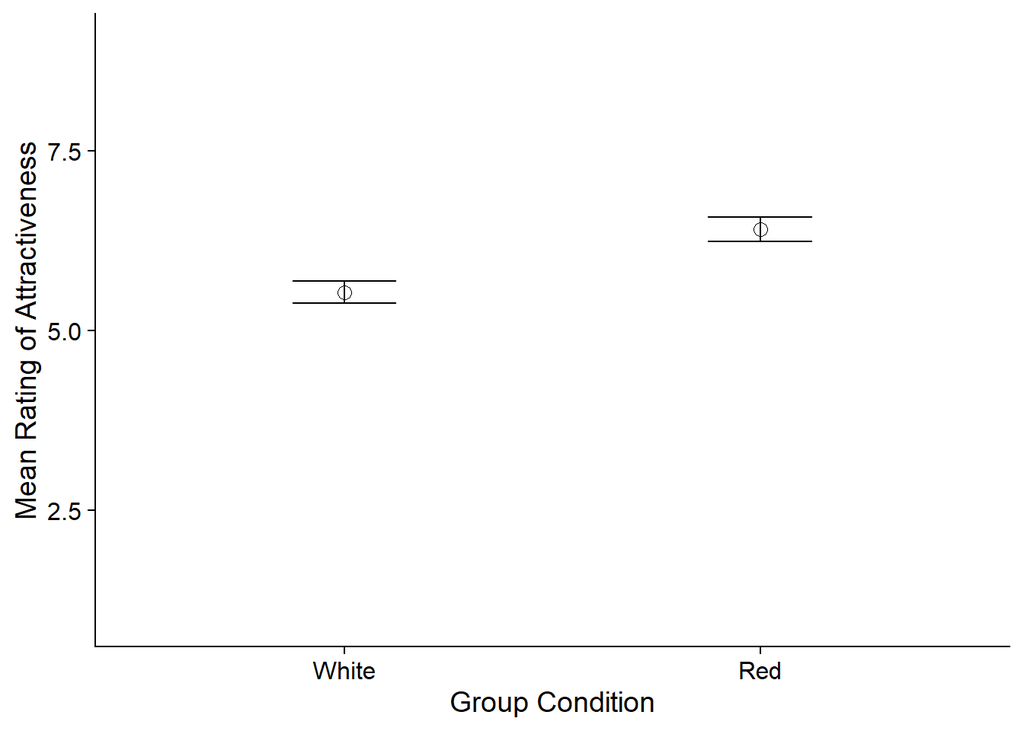

# Discussion

This study gives insight into whether the colour red affects women’s physical attraction to men by showing that on the first impression, the immediate attraction a woman feels towards a man is significantly greater if the man is viewed in conjuncture with the colour red. This experiment was a replication of the first experiment conducted by Elliot et al. (2010), except, with a greater number of participants and the use of 3 models as opposed to just 1, this study alongside the other 6 experiments conducted by Elliot et al. (2010) both show patterns of the colour red being linked to attraction towards men, across a multitude of countries and cultures. As a result of these pairing well, the effect of the presence of publication bias found by Francis (2013) is dampened and the question of “whether the colour red influences women’s ratings of men’s attributes” has an increased backing of strong evidence of behind it as shown by the phenomena’s consistency across groups when handled in a similar fashion. Hesslinger et al. (2015), however, challenges the ecological validity of this study by applying the red effect through a similarly adapted version of the original Elliot et al. (2010) study, one being a close replication of the original experiment, including the same stimulus materials, but also another, instead of using a full-body image of the men to also show their clothing as well as including the added dimension of perceived status when assessing the model. Unlike this study, however, both of these investigations yielded statistically insignificant results, suggesting a lower ecological validity to the red effect than originally conceived- nonetheless, this isn’t to say that the red effect is non-existent, more-so that it is not as omnipotent as it may seem when looking at our study alone. And so, while this study found that there is a significant increase in a man’s initial attractiveness rating, and there may be an evolutionary basis in the colour red being used as part of sexual signalling in primates (Setchell et al., 2006), when being briefly viewed whilst coupled with the colour red, the highly specific and artificial nature of the study causes the seemingly profound results to have little ecological validity, making them more or less meaningless when applied to the real world and so it is inconclusive whether the red effect is a significant contributory factor when deciding attractiveness. Possible alterations for future studies to solve some of these ecological validity issues could be by using a greater number of contexts in which the colour red is present such as that used by (Peperkoorn et al., 2016) in which they investigated the red effect on men by altering not just background colour, like in this study, but also the colour of clothing, facial features (e.g. women’s lips (Stephen & McKeegan, 2010)), and even the effect of object colour as also used by(Lin, 2014). This would avoid the main issue of this experiment by applying the red effect in contexts with high ecological validity and thus result in a study that is more meaningful in its results. Another alteration to this study would be to digitalise the whole study as this allows for more time accurate viewings, possible increase in colour consistency due to it being unaffected by lighting, and by digitalising the study can become more widely available through the use of the internet, allowing for a greater number of participants, and therefore greater reliability, this would also eliminate the minor cost of having to print the photos and would mean that no space would be required for the study to be held as participants can complete the study from home. To conclude, while the findings of this study indicated a significant increase in female attraction towards men in conjunction with the colour red, the low ecological validity of the study hinders it from being of any significant value- however, this does provide a strong basis for the existence of a red effect when women view men and so further investigation is still to be conducted.

# References

Elliot, A. J., & Maier, M. A. (2013). The red-attractiveness effect, applying the ioannidis and trikalinos (2007b) test, and the broader scientific context: A reply to francis (2013). Journal of Experimental Psychology: General, 142(1), 297-300. doi:http://dx.doi.org/10.1037/a0029592

Elliot, A. J., Niesta Kayser, D., Greitemeyer, T., Lichtenfeld, S., Gramzow, R. H., Maier, M. A., & Liu, H. (2010). Red, rank, and romance in women viewing men. Journal of Experimental Psychology: General, 139(3), 399–417. https://doi.org/10.1037/a0019689

Francis, G. (2013). Publication bias in “Red, rank, and romance in women viewing men,” by elliot et al. (2010). Journal of Experimental Psychology: General, 142(1), 292-296. doi:http://dx.doi.org/10.1037/a0027923

Hesslinger, V. M., Goldbach, L., & Carbon, C.-C. (2015). Men in red: A reexamination of the red-attractiveness effect. Psychonomic Bulletin & Review, 22(4), 1142–1148. https://doi.org/10.3758/s13423-015-0866-8

Lin, H. (2014). Red-colored products enhance the attractiveness of women. Displays, 35(4), 202–205. https://doi.org/10.1016/j.displa.2014.05.009

Peperkoorn, L. S., Roberts, S. C., & Pollet, T. V. (2016). Revisiting the Red Effect on Attractiveness and Sexual Receptivity: No Effect of the Color Red on Human Mate Preferences. Evolutionary Psychology, 14(4), 1474704916673841. https://doi.org/10.1177/1474704916673841

Setchell, J. M., Jean Wickings, E., & Knapp, L. A. (2006). Signal content of red facial coloration in female mandrills (Mandrillus sphinx). Proceedings of the Royal Society B: Biological Sciences, 273(1599), 2395–2400. https://doi.org/10.1098/rspb.2006.3573

Stephen, I. D., & McKeegan, A. M. (2010). Lip Colour Affects Perceived Sex Typicality and Attractiveness of Human Faces. Perception, 39(8), 1104–1110. https://doi.org/10.1068/p6730